# Évaluation des modèles

# Importation des Packages et fonctions externes

```r
source("./0_packages.R")

# library(doMC)
# registerDoMC(cores = 1)
```

# Importation des données

```r
load("./../data/bases_35features.RData")
load("./../data/none_lgb_info.RData") # performance du LGB
load("./../data/up_lgb_info.RData") # performance du LGB avec scale_pos_weight

train_id = train$id
train_XY = train %>% select(-id)
train_X  = train %>% select(-id, -target)
train_Y  = train$target %>% as.numeric()
train_Y  = train_Y - 1

test_id = test$id
test_X  = test %>% select(-id, -target)
test_Y  = test$target %>% as.numeric()
test_Y  = test_Y - 1
```

# Zone de stockage

Les modèles sont stockés en dehors du répertoire github car trop lourds.

```r
path_exportation = file.path("/home/psqrt/Téléchargements/000")
```

# Importation / Calcul de la performance (gini) + ROC de tous les modèles

```r
df_score_modeles = data.frame("Method"     = character(),
                              "Sampling"   = character(),
                              "Train"      = numeric(),
                              "Validation" = numeric(),
                              "Test"       = numeric(),
                              stringsAsFactors = F)

df_roc_modeles = data.frame("Obs" = train_Y,
                            stringsAsFactors = F)



donnees_modeles = list.files(path_exportation)
donnees_modeles = donnees_modeles[-grep("ada|kppv|txt", donnees_modeles)] # on ne prend pas ada et kppv (trop lents)


for (rdata_file in donnees_modeles){
  modele = gsub(".RData", "", rdata_file)
  print(modele)
  load(file.path(path_exportation, rdata_file))

  param_tune = unlist(get(modele)$bestTune)
  scores_cv = get(modele)$pred

  if (grepl("rf", modele)){
    param_tune[grep("splitrule", names(param_tune))] = "gini"
  }
  for (i in 1:length(param_tune)){
    print(names(param_tune)[i])
    scores_cv = scores_cv %>%
      filter(get(names(param_tune)[i]) == param_tune[i])
  }
  scores_cv = scores_cv %>%
    arrange(rowIndex) %>%
    select(yes)
  colnames(scores_cv) = modele

  df_roc_modeles = df_roc_modeles %>%
    bind_cols(scores_cv)
  rm(list = get("modele"))
}
```

Il manque les prédictions light gbm (none et up).

```r
set.seed(1234)
params_lgb = list(
  objective        = "binary",                            # type of exercise
  metric           = "auc",                               # metric to be evaluated
  learning_rate    = 0.01,                                # shrinkage rate
  max_depth        = up_lgb_best_tune$max_depth,          # max depth for tree model (used to deal with over-fitting)
  num_leaves       = up_lgb_best_tune$num_leaves,         # max number of leaves (nodes) in one tree
  scale_pos_weight = 26,                                  # weight positive class
  min_data_in_leaf = 1,                                   # min number of data in one leaf (used to deal with over-fitting)
  feature_fraction = up_lgb_best_tune$feature_fraction,   # randomly select part of the features per iteration
  bagging_fraction = up_lgb_best_tune$bagging_fraction,   # randomly select part of the data without resampling
  bagging_freq     = 5,                                   # if != 0, enables bagging, performs bagging at every k iteration
  num_threads      = 6                                    # number of cpu cores (not threads) to use
)

up_lgb_cv_stacking = lgb.cv(
  params                = params_lgb,         # hyperparameters
  data                  = train_XY_lgb,       # lgb.Dataset object for training
  eval                  = lgb.normalizedgini, # custom metric, additionnal to first metric
  nrounds               = 536,                # maximum iterations (obtenir 536 en itérant jusqu'à 1000 puis placer la bonne valeur)
  early_stopping_rounds = 50,                 # if metric evaluation doesn't increase
  verbose               = 1,                  # enable verbose
  eval_freq             = 50,                 # verbose every n iterations
  nfold                 = 5                   # k-folds CV
)
```

```r
# save(up_lgb_cv_stacking, file = "./../data/up_lgb_cv_stacking.RData")
load("./../data/up_lgb_cv_stacking.RData")
```

On récupère les prédictions CV.

Source pour la fonction d’extraction des prédictions : https://github.com/Microsoft/LightGBM/issues/283

```r
up_lgb_cv_stacking_valid_preds = get_lgbm_cv_preds(up_lgb_cv_stacking)

# on enregistre les prédictions pour la courbe roc plus tard
# save(up_lgb_cv_stacking_valid_preds, file = "./../data/up_lgb_stacking_valid_preds.RData")
```

```r
load("./../data/none_lgb_stacking_valid_preds.RData")
load("./../data/up_lgb_stacking_valid_preds.RData")
load("./../data/none_glm_stacking_valid_preds.RData")
load("./../data/none_combi_valid_preds.RData")
```

```r
df_roc_modeles = df_roc_modeles %>%
  bind_cols("none_lgb_model"      = none_lgb_cv_stacking_valid_preds) %>%
  bind_cols("up_lgb_model"        = up_lgb_cv_stacking_valid_preds) %>%
  bind_cols("none_glmstack_model" = none_glm_stacking_valid_preds) %>%
  bind_cols("none_combi_model"    = none_combi_valid_preds)

# save(df_roc_modeles, file = "./../data/df_roc_modeles.RData")
```

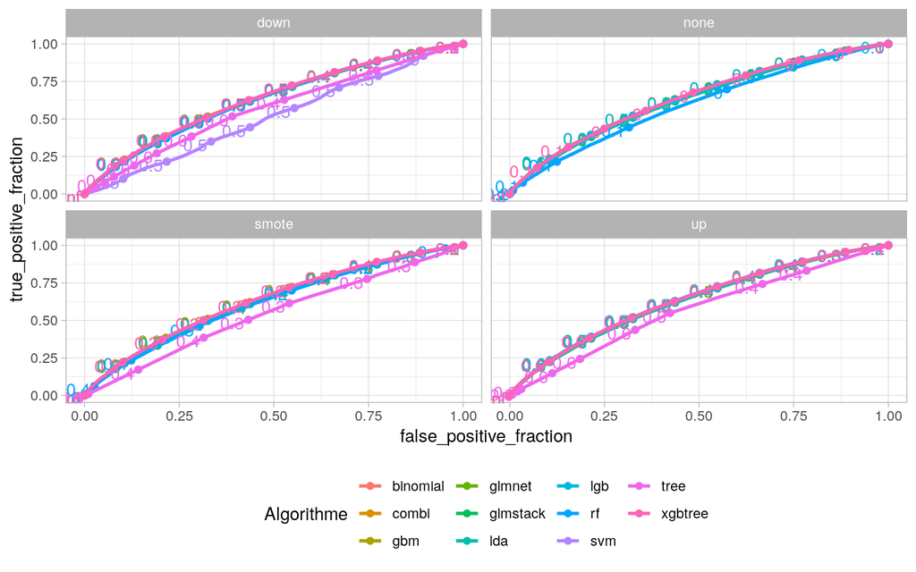

```r
load("./../data/df_roc_modeles.RData") # info pour roc curve

df_roc = df_roc_modeles %>%
  # select(contains("none"), Obs) %>%
  gather(key = "Method", value = "score", -Obs) %>%
  mutate(Sampling = sub("_.*", "", Method)) %>%
  mutate(Algorithme = stringr::str_match(Method, ".*_(.*?)_model")[, 2])

#tout
df_roc %>% ggplot() +
  aes(d = Obs, m = score, color = Algorithme) +
  geom_roc() +
  theme(legend.position = "bottom") +
  facet_wrap(~ Sampling, nrow = 2)
```

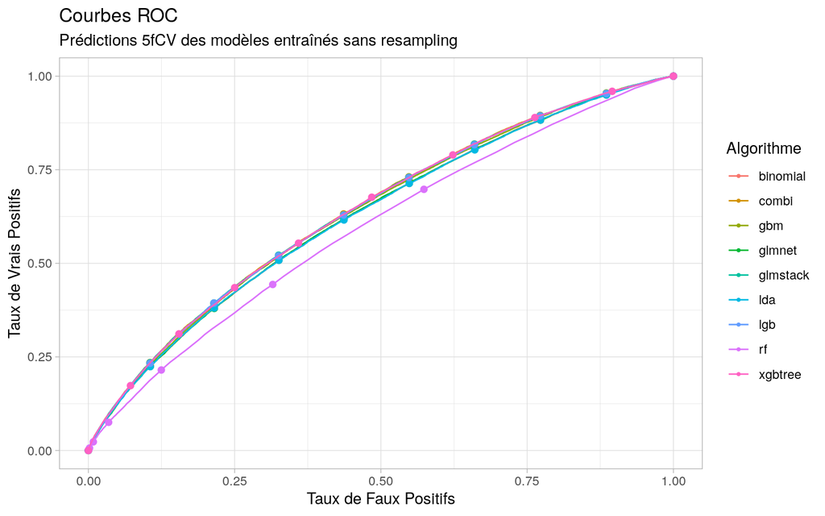

```r
#none
df_roc %>%
  filter(Sampling == "none") %>%
  ggplot() +
  aes(d = Obs, m = score, color = Algorithme) +
  geom_roc(size = 0.5, labels = F) +
  xlab("Taux de Faux Positifs") +
  ylab("Taux de Vrais Positifs") +
  ggtitle("Courbes ROC", subtitle = "Prédictions 5fCV des modèles entraînés sans resampling")
```

```r
# save(df_score_modeles, file = "./../data/df_score_modeles.RData")

load("./../data/df_score_modeles.RData")                         # info de tous les modèles sauf ...
load("./../data/none_lgb_info.RData")                          # info lgb none
load("./../data/up_lgb_info.RData")                            # info lgb up
load("./../data/glm_stacking_model_info.RData")                # info stacking
load("./../data/combinaison_model_info.RData")                 # info combi
load(file.path(path_exportation, "none_ada_model_trick.RData"))  # none_ada_best_gini
load(file.path(path_exportation, "smote_ada_model_trick.RData")) # smote_ada_best_gini
load(file.path(path_exportation, "down_ada_model_trick.RData"))  # down_ada_best_gini

ada_lignes_df = data.frame("Method"     = c("ada", "ada", "ada"),
                           "Sampling"   = c("none", "smote", "down"),
                           "Train"      = rep(NA, 3),
                           "Validation" = c(none_ada_best_gini, smote_ada_best_gini, down_ada_best_gini),
                           "Test"       = rep(NA, 3),
                           stringsAsFactors = F)

df_score_modeles = df_score_modeles %>%
  bind_rows(none_lgb_info) %>%
  bind_rows(up_lgb_info) %>%
  bind_rows(ada_lignes_df) %>%
  bind_rows(glm_stacking_model_info) %>%
  bind_rows(combinaison_model_info)
```

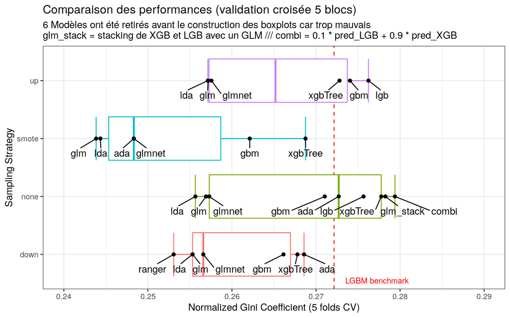

```r
df_score_modeles %>%
  filter(Validation > 0.23) %>% # on retire les modèles trop mauvais
  ggplot() +
  aes(x = Sampling, y = Validation, group = Sampling, label = Method) +
  geom_hline(yintercept = 0.2721429, color = "red", linetype = 2) +
  stat_boxplot(geom = "errorbar", aes(color = Sampling)) +
  geom_boxplot(aes(color = Sampling)) +
  geom_point() +
  geom_text_repel(direction = "x", nudge_x = -0.25) +
  coord_flip() +
  ylim(c(0.24, 0.29)) +
  xlab("Sampling Strategy") +
  ylab("Normalized Gini Coefficient (5 folds CV)") +
  annotation_custom(grob = textGrob(label = "LGBM benchmark",
                                    gp = gpar(fontsize = 9, col = "red")),
                    xmin = -3.5,
                    ymin = 0.262) +
  theme_bw() +
  theme(legend.position = "none") +
  ggtitle(label = "Comparaison des performances (validation croisée 5 blocs)",
          subtitle = "6 Modèles ont été retirés avant le construction des boxplots car trop mauvais \nglm_stack = stacking de XGB et LGB avec un GLM /// combi = 0.1 * pred_LGB + 0.9 * pred_XGB")
```

## Modèle retenu

Le modèle retenu est le combiné. Le gini associé à l’échantillon test est :

```r
cat("Coefficient Normalisé de Gini sur l'échantillon test :\n", df_score_modeles$Test[which(df_score_modeles$Method == "combi")])
```

```
Coefficient Normalisé de Gini sur l'échantillon test :
 0.2880895
```

Les prédictions en CV sont récupérées. Maintenant il s’agit de voir quel threshold appliquer pour maximiser un objectif (F1 par exemple).

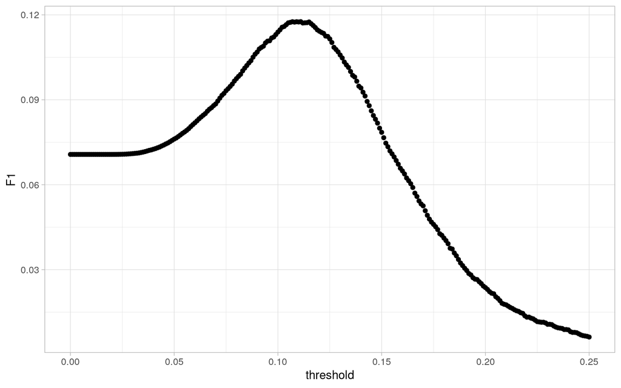

```r
df_threshold = data.frame("target" = train_Y,
                          "pred_combi" = none_combi_valid_preds)

df_f1 = data.frame("threshold" = seq(0, 0.25, 0.001),
                   "F1" = as.numeric(NA))
for (threshold in seq(0, 0.25, 0.001)){
  df_f1[which(df_f1$threshold == threshold), "F1"] = f1Score(df_threshold$target, df_threshold$pred_combi, cutoff = threshold)
}

df_f1 %>%
  ggplot() +
  aes(x = threshold,
      y = F1) +
  geom_point()
```

```r
best_threshold_cv = df_f1 %>%
  arrange(-F1) %>%
  slice(1)

df_threshold = df_threshold %>%
  mutate(label = if_else(pred_combi > best_threshold_cv$threshold, 1, 0))

caret::confusionMatrix(factor(df_threshold$label), factor(df_threshold$target), positive = "1", mode = "everything")
```

```
Confusion Matrix and Statistics

          Reference
Prediction      0      1
         0 355977  11478
         1  45403   3790

               Accuracy : 0.8635
                 95% CI : (0.8624, 0.8645)
    No Information Rate : 0.9634
    P-Value [Acc > NIR] : 1

                  Kappa : 0.0653

 Mcnemar's Test P-Value : <2e-16

            Sensitivity : 0.248232
            Specificity : 0.886883
         Pos Pred Value : 0.077043
         Neg Pred Value : 0.968764
              Precision : 0.077043
                 Recall : 0.248232
                     F1 : 0.117590
             Prevalence : 0.036645
         Detection Rate : 0.009096
   Detection Prevalence : 0.118068
      Balanced Accuracy : 0.567557

       'Positive' Class : 1
```

On atteint un score F1 de 0.118 sachant qu’on arrive à identifier correctement un label positif sur 4 en réalité. En appliquant ce même threshold pour l’échantillon test, on trouve :

```r
load("./../data/none_combi_test_preds.RData")
df_threshold_test = data.frame("target" = test_Y,
                               "pred_combi" = df_test_combi$combinaison)

df_threshold_test = df_threshold_test %>%
  mutate(label = if_else(pred_combi > best_threshold_cv$threshold, 1, 0))

caret::confusionMatrix(factor(df_threshold_test$label), factor(df_threshold_test$target), positive = "1", mode = "everything")
```

```
Confusion Matrix and Statistics

          Reference
Prediction      0      1
         0 152542   4827
         1  19596   1599

               Accuracy : 0.8632
                 95% CI : (0.8616, 0.8648)
    No Information Rate : 0.964
    P-Value [Acc > NIR] : 1

                  Kappa : 0.0641

 Mcnemar's Test P-Value : <2e-16

            Sensitivity : 0.248833
            Specificity : 0.886161
         Pos Pred Value : 0.075442
         Neg Pred Value : 0.969327
              Precision : 0.075442
                 Recall : 0.248833
                     F1 : 0.115781
             Prevalence : 0.035987
         Detection Rate : 0.008955
   Detection Prevalence : 0.118697
      Balanced Accuracy : 0.567497

       'Positive' Class : 1
```

On trouve un score F1 de 0.1158 pour le test, et un Recall de 0.2488. Les résultats sont stables entre la validation et le test.

Étape 6